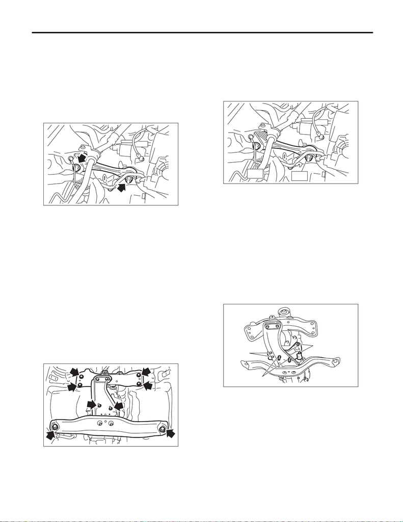

5. Transmission Mounting Sys-

tem

A: REMOVAL

1. PITCHING STOPPER

1) Disconnect the ground cable from battery.

2) Remove the intercooler. <Ref. to IN(STI)-13,

REMOVAL, Intercooler.>

3) Remove the pitching stopper.

2. CROSSMEMBER AND CUSHION RUB-

BER

1) Disconnect the ground cable from battery.

2) Lift up the vehicle.

3) Remove the transmission under cover.

4) Remove the center exhaust pipe. <Ref. to

EX(STI)-7, REMOVAL, Center Exhaust Pipe.>

5) Remove the rear exhaust pipe and muffler.

<Ref. to EX(STI)-12, REMOVAL, Rear Exhaust

Pipe.> <Ref. to EX(STI)-14, REMOVAL, Muffler.>

6) Remove the heat shield cover.

7) Set the transmission jack under the transmission

case.

CAUTION:

Always support the transmission case with a

transmission jack.

8) Remove the front crossmember and the rear

crossmember.

9) Remove the transmission cushion rubber.

B: INSTALLATION

1. PITCHING STOPPER

1) Install the pitching stopper.

Tightening torque:

T1: 50 N·m (5.1 kgf-m, 36.9 ft-lb)

T2: 58 N·m (5.9 kgf-m, 42.8 ft-lb)

2) Install the intercooler. <Ref. to IN(STI)-14, IN-

STALLATION, Intercooler.>

3) Connect the battery ground terminal.

2. CROSSMEMBER AND CUSHION RUB-

BER

1) Install the transmission cushion rubber to the

transmission, and tighten the bolt (A).

2) Install the transmission cushion rubber to the

center crossmember, and temporarily tighten the

nut (B).

Tightening torque:

Bolt (A)

35 N·m (3.6 kgf-m, 25.8 ft-lb)

3) Tighten the mounting bolts for front crossmem-

ber and rear crossmember.

T1

T2

(A)

(A)

(B)

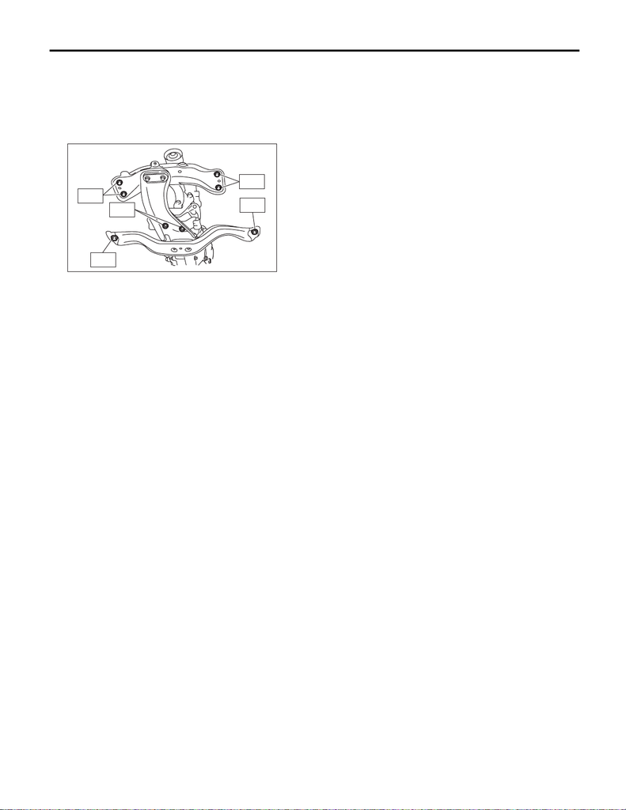

4) Tighten the transmission cushion rubber mount-

ing nut.

Tightening torque:

T1: 35 N·m (3.6 kgf-m, 25.8 ft-lb)

T2: 70 N·m (7.1 kgf-m, 51.6 ft-lb)

T3: 140 N·m (14.3 kgf-m, 103 ft-lb)

5) Remove the transmission jack.

6) Install the heat shield cover.

Tightening torque:

18 N·m (1.8 kgf-m, 13.3 ft-lb)

7) Install the rear exhaust pipe and muffler. <Ref. to

EX(STI)-12, INSTALLATION, Rear Exhaust Pipe.>

<Ref. to EX(STI)-15, INSTALLATION, Muffler.>

8) Install the center exhaust pipe. <Ref. to EX(STI)-

8, INSTALLATION, Center Exhaust Pipe.>

C: INSPECTION

Perform the following inspection procedures and

repair or replace faulty parts.

1. PITCHING STOPPER

Check the pitching stopper for bends or damage.

Check that the rubber is not stiff, cracked or other-

wise damaged.

2. CROSSMEMBER AND CUSHION RUB-

BER

Check the crossmember for bending or damage.

Check that the cushion rubber is not stiff, cracked,

or otherwise damaged.

T2

T2

T3

T3

T1